# StatCourse_spatial

Stefano Larsen

3/18/2021

```r
library(vegan)
library(tidyverse)
library(gstat)
library(sp)
library(raster)
library(maptools)
library(nlme)
```

## Exploring autocorrelation [in time & space]

###Example with temporal autocorrelation (time-series)

Simulate some correlated noise with AR(1)

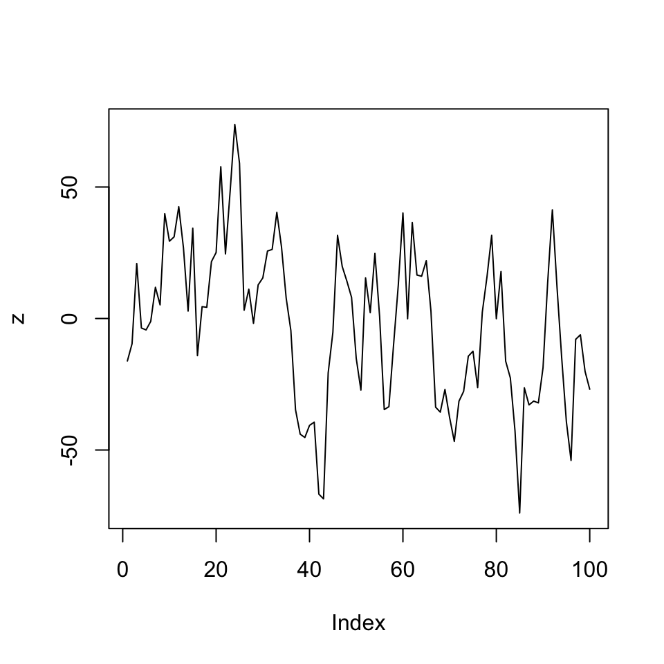

```r
set.seed(2)
z<-w<-rnorm(100, sd=18)# noise
for (t in 2:100) z[t]<- 0.8 * z[t-1] + w[t]# the AR(1) process

# the z[t] is the AR(1) process; zt = 0.8*zt-1 + wt, with wt = gaussian white noise with var = 20

plot(z, type='l')
```

Lets simulate a time series using the autocorrelated noise.

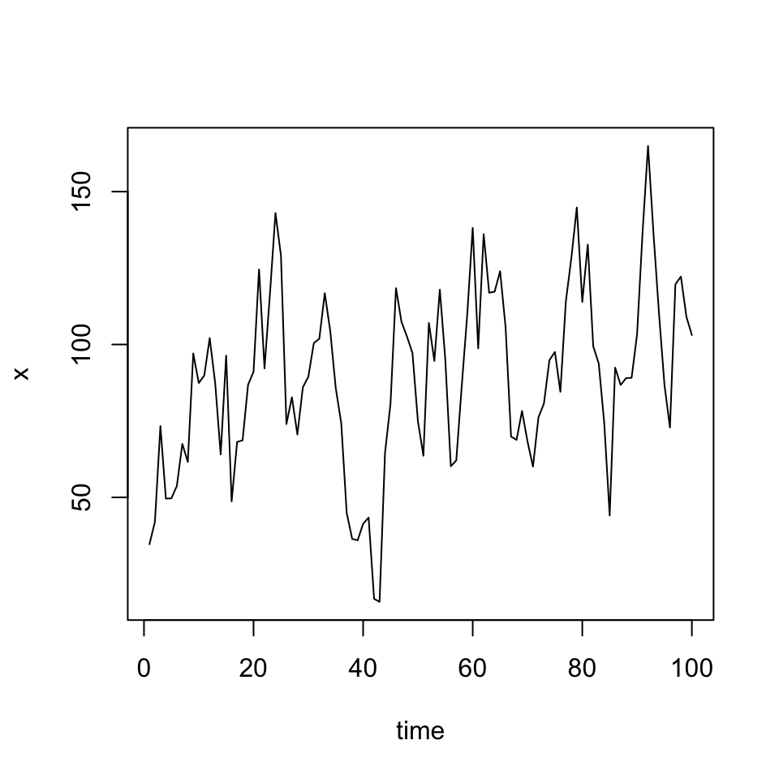

```r
Time <- 1:100
x <- 50 + 0.8 * Time + z # simulate time-series with autocor and noise and positive trend
plot(x, xlab="time", type="l")
```

There is apparent trend. Let’s examine it. Fit a linear model to the data (ignoring autocorrelation)

```r
x.lm<-lm(x~Time)
summary(x.lm) # estimate of slope = 0.38
```

```
##
## Call:
## lm(formula = x ~ Time)
##
## Residuals:
##     Min      1Q  Median      3Q     Max
## -70.013 -18.180   0.558  18.119  64.486
##
## Coefficients:
##             Estimate Std. Error t value Pr(>|t|)
## (Intercept) 69.27189    5.52556  12.537  < 2e-16 ***
## Time         0.38499    0.09499   4.053 0.000101 ***
## ---
## Signif. codes:  0 '***' 0.001 '**' 0.01 '*' 0.05 '.' 0.1 ' ' 1
##
## Residual standard error: 27.42 on 98 degrees of freedom
## Multiple R-squared:  0.1435, Adjusted R-squared:  0.1348
## F-statistic: 16.43 on 1 and 98 DF,  p-value: 0.0001015
```

```r
# sd error of estimates: intercept=5.5 and slope=0.09
```

Linear regression assumes independence of observations and residuals. Let’s check if this holds here.

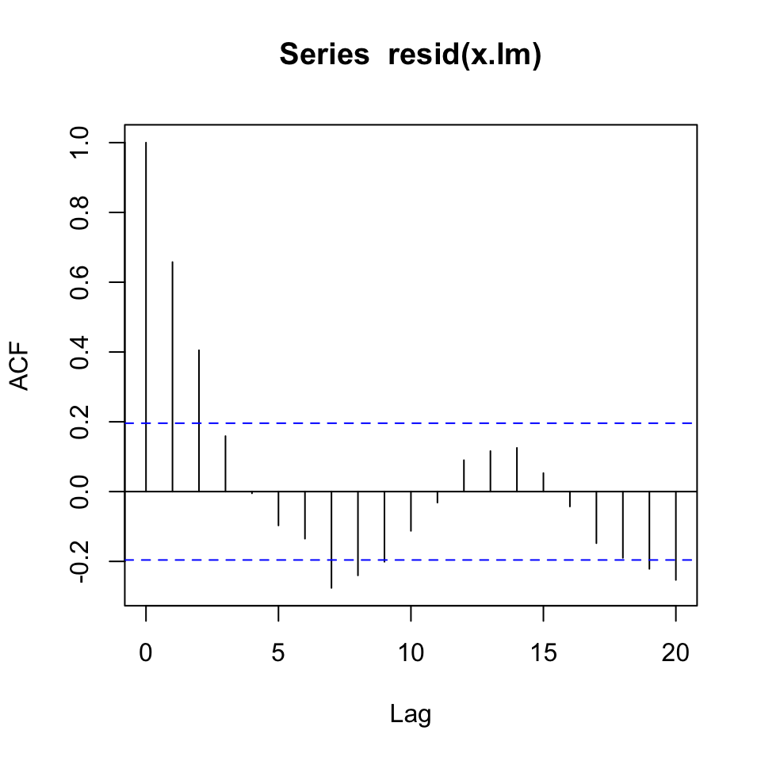

```r
acf(resid(x.lm))
```

Let see the partial residual plot

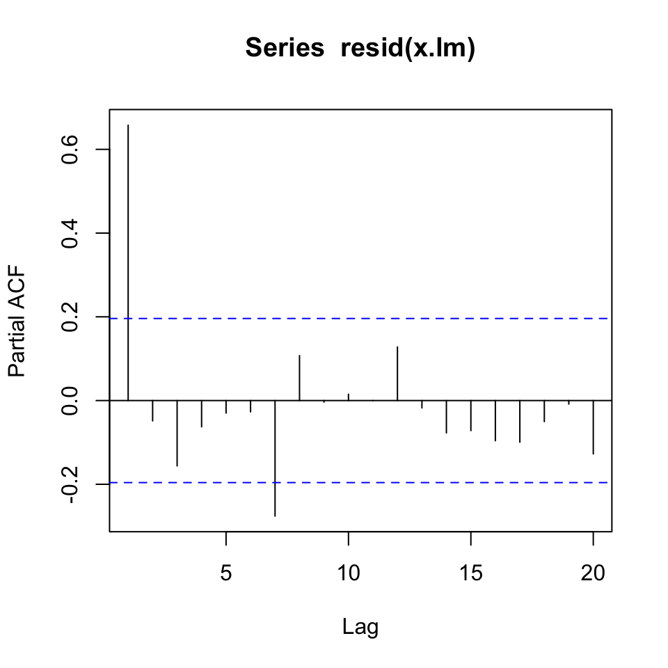

```r
pacf(resid(x.lm)) # partial acf shows lag-1 autocorrelation (as expected)
```

### this means that our estimation of the coefficients for timeseries trends can be wrong

Fitting a generalised least-square model, taking AR into account. What happens to the standard errors of the estimated parameters? The temporal trend is now bordeline significant and the SD of parameters larger

```r
#library(nlme)
x.gls <- gls(x~Time, cor=corAR1(0.7)) # fitting autocorrelation of order 1 (Here using cor=0.7 because we knew already)
summary(x.gls)
```

```
## Generalized least squares fit by REML
##   Model: x ~ Time
##   Data: NULL
##        AIC      BIC    logLik
##   890.3855 900.7254 -441.1928
##
## Correlation Structure: AR(1)
##  Formula: ~1
##  Parameter estimate(s):
##       Phi
## 0.6975682
##
## Coefficients:
##                Value Std.Error  t-value p-value
## (Intercept) 66.44187 12.931722 5.137898  0.0000
## Time         0.42370  0.219782 1.927822  0.0568
##
##  Correlation:
##      (Intr)
## Time -0.858
##
## Standardized residuals:
##           Min            Q1           Med            Q3           Max
## -2.4030369405 -0.6186876673  0.0006914511  0.6725653520  2.3171444898
##
## Residual standard error: 28.65019
## Degrees of freedom: 100 total; 98 residual
```

```r
# the st errors of parameters is much larger now: intercept=12.9, slope= 0.21
```

Which is the “best” model? Ask AIC

```r
AIC(x.lm)
```

```
## [1] 950.0281
```

```r
AIC(x.gls)# better suppored model based on AIC
```

```
## [1] 890.3855
```

Plot both model prediction. Trends are only marginally different, but the confidence intervals are larger whan accounting for temporal autocorrelation. Hence the trends become non-significant at alpha=0.05

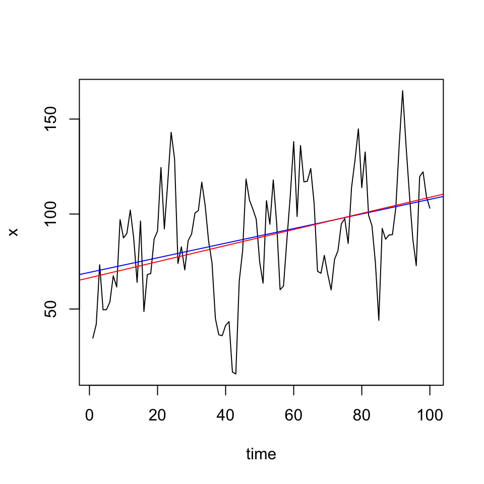

```r
plot(x, xlab="time", type="l")
abline(a=coef(x.lm)[1],b=coef(x.lm)[2], col='blue' )
abline(a=coef(x.gls)[1],b=coef(x.gls)[2], col='red' )
```

### SPatial Autocorrelation

####Spatial structure is more complex than temporal; there are two dimensions

Let’s simulate some sparse coordinates [with no real meaning!]

```r
Long.x=seq(from=100, to=120, 0.2)+rnorm(101, 0, 4)
Lat.y=seq(20,40, 0.2)+rnorm(101, 0, 4)

#plot(Long.x, Lat.y)
```

Simulate some spatially structured variable (e.g. bird diversity) using the *ncf::rmvr.spa* function Then simulate some environmental variable correlated with latitude

```r
install.packages('ncf')
```

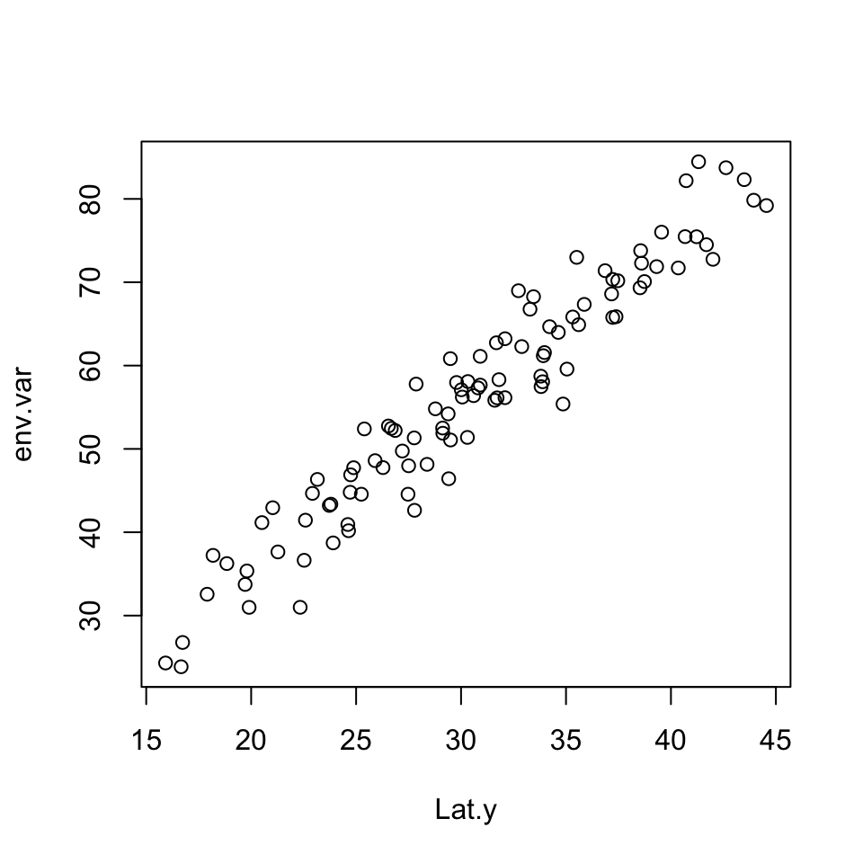

```r
library(ncf)
div.ncf=rmvn.spa(Long.x, Lat.y, 20, method = "exp", nugget = 1)# we call it div.nfc

div.ncf=div.ncf-min(div.ncf) # dirty trick to include only positive values


env.var=1+2*Lat.y -0.05*(Long.x)+rnorm(101,0,4)# environmental variable reflecting lat and long

plot(Lat.y,env.var) # exagerated trend of environmental variable with latitude
```

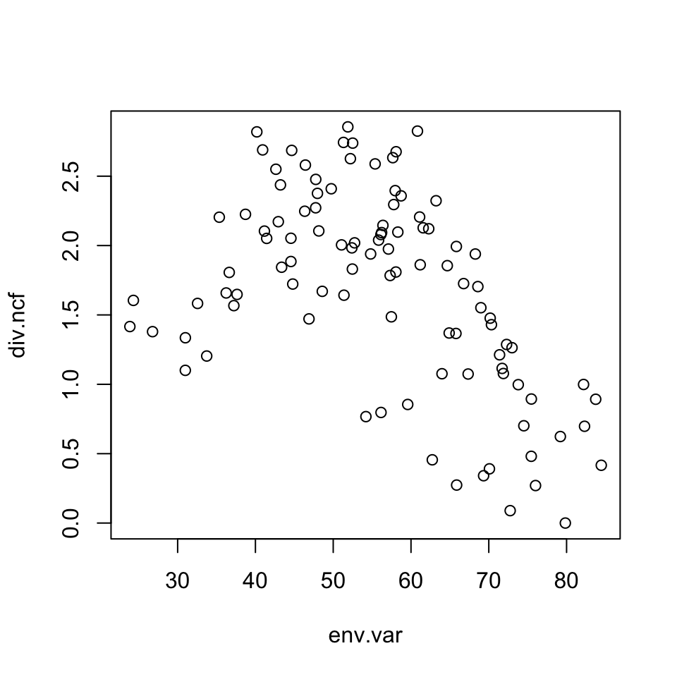

```r
plot(div.ncf~env.var)
```

Put the data together, coordinates, environmental variable and diversity.

```r
bird.diversity=data.frame(Lat.y=Lat.y, Long.x=Long.x, Bird_div=div.ncf, Env.var=env.var)
```

Specify what are the coordinates, for plotting variograms.

```r
coordinates(bird.diversity)=~Long.x+Lat.y
```

Lets have a look at the variogram. Looks pretty strong autocorrelation pattern.

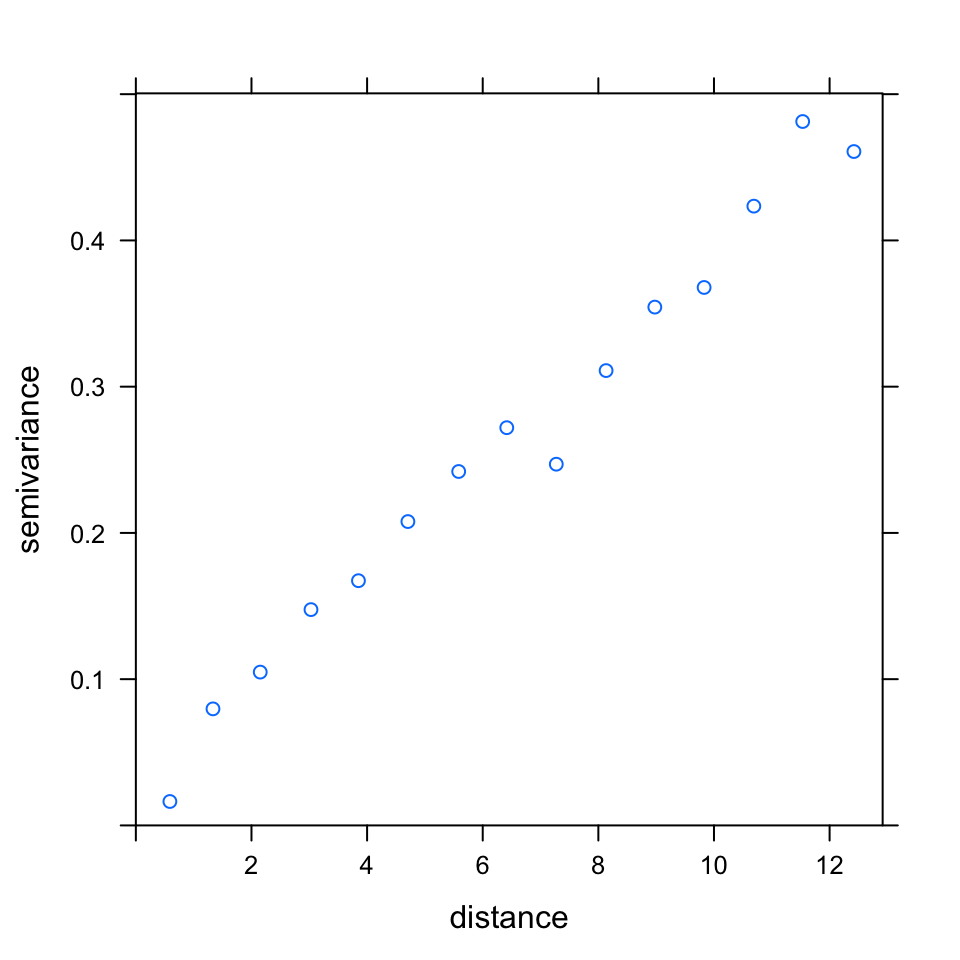

```r
plot(gstat::variogram(Bird_div~ Long.x+Lat.y , bird.diversity))
```

Fit a simple model with no spatial correlation.

```r
model1 <- gls(log(Bird_div + 1) ~ log(env.var + 1) , data = bird.diversity )
summary(model1)
```

```
## Generalized least squares fit by REML
##   Model: log(Bird_div + 1) ~ log(env.var + 1)
##   Data: bird.diversity
##        AIC      BIC    logLik
##   38.23573 46.02109 -16.11786
##
## Coefficients:
##                       Value Std.Error   t-value p-value
## (Intercept)       2.8910344 0.4098826  7.053323       0
## log(env.var + 1) -0.4839385 0.1019691 -4.745933       0
##
##  Correlation:
##                  (Intr)
## log(env.var + 1) -0.998
##
## Standardized residuals:
##        Min         Q1        Med         Q3        Max
## -2.7788637 -0.5406176  0.2248312  0.7583186  1.6211657
##
## Residual standard error: 0.2754148
## Degrees of freedom: 101 total; 99 residual
```

Check the residual variogram from the model. Some clear pattern of correlated observation at short distances.

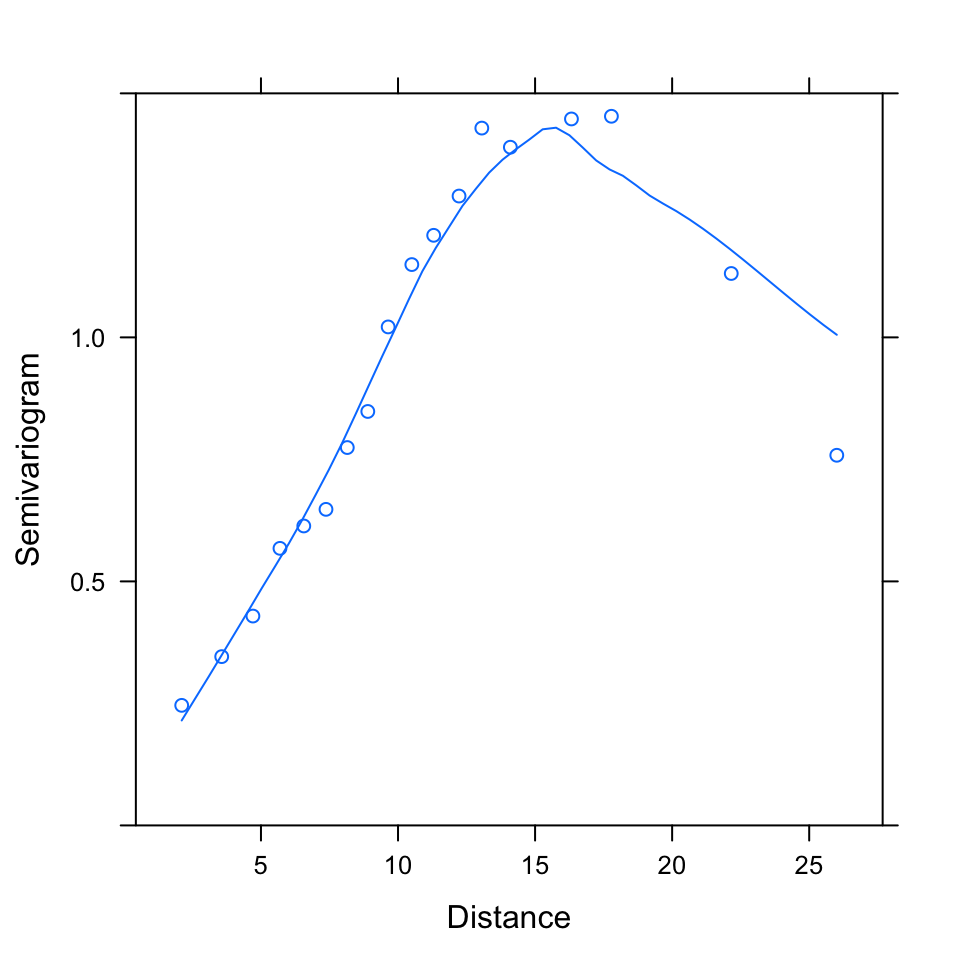

```r
plot(nlme::Variogram(model1, form = ~Long.x + Lat.y, resType = "normalized"), ylim=c(0,1.5))
```

```r
# nearby locations show rather low variation. A clear patter of spatial autocorrelation
```

Now, lets fit a gls model including Gaussian autocorrelation function

```r
model.sp.gauss<-gls( log(Bird_div + 1) ~ log(Env.var + 1) , correlation = corGaus(form = ~Long.x + Lat.y, nugget=T), data = bird.diversity )
summary(model.sp.gauss)
```

```
## Generalized least squares fit by REML
##   Model: log(Bird_div + 1) ~ log(Env.var + 1)
##   Data: bird.diversity
##         AIC       BIC   logLik
##   -84.47821 -71.50261 47.23911
##
## Correlation Structure: Gaussian spatial correlation
##  Formula: ~Long.x + Lat.y
##  Parameter estimate(s):
##      range     nugget
## 5.67279707 0.08651798
##
## Coefficients:
##                       Value Std.Error  t-value p-value
## (Intercept)       1.6850856 0.5597306  3.01053  0.0033
## log(Env.var + 1) -0.2219529 0.1391118 -1.59550  0.1138
##
##  Correlation:
##                  (Intr)
## log(Env.var + 1) -0.984
##
## Standardized residuals:
##         Min          Q1         Med          Q3         Max
## -2.20111101 -0.03500116  0.74791854  1.11498400  1.77259524
##
## Residual standard error: 0.3226371
## Degrees of freedom: 101 total; 99 residual
```

And the check the residual variogram of this spatially explicit model. The patterns are different, and no real trend with distance is evident.

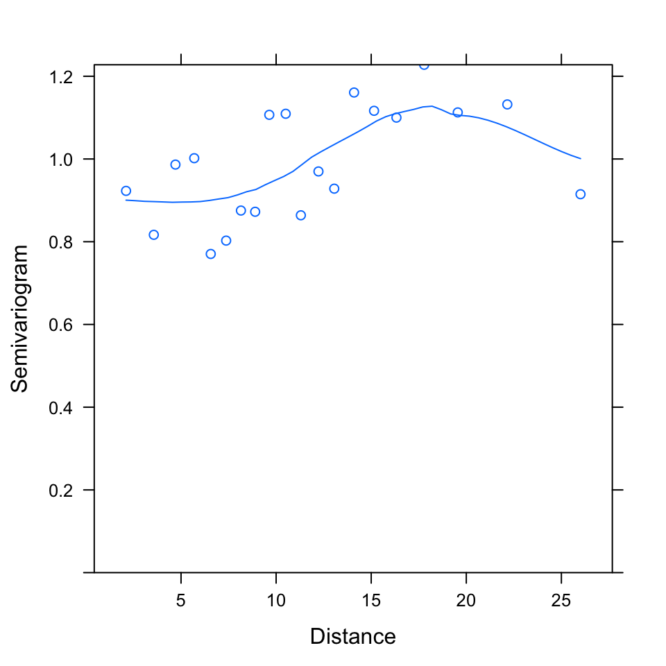

```r
plot(nlme::Variogram(model.sp.gauss, form = ~Long.x + Lat.y, resType = "normalized"))
```

Which model is favored according to AIC. Clear support for model2 (lower AIC).

```r
AIC(model1, model.sp.gauss)
```

```
##                df       AIC
## model1          3  38.23573
## model.sp.gauss  5 -84.47821
```

We can visually compare the fits of the two model. Most of the apparent effect of environmental variable on bird diversity seems to come from an autocorrelation process

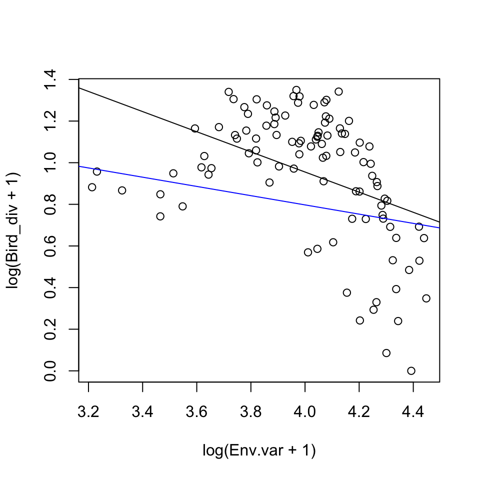

```r
plot(log(Bird_div+1)~log(Env.var+1), bird.diversity)
abline(a=coef(model1)[1], b=coef(model1)[2]) # add fit from model1 (w/o spatial autocor)
abline(a=coef(model.sp.gauss)[1], b=coef(model.sp.gauss)[2], col="blue") #add the model fit from the gaussian autocor model
```